# Gender Gap in China

4/25/2019

## Problem Statement

- Whether there is a gender gap in job market in terms of income and labor force participation
- By safeguarding the right of women to equal employment, we thus help to eliminate gender discriminiation and promote equality,

## Background

- Growth in the Chinese economocy has generated great wealth and development in social equality, however, issues still persist:
  1. Employment competition
  2. Oversupplied workforce
  3. Workplace Gender discrimination

## Research Design and Approah

- Adopted survey data from the China Nutrition and Health Survey
- Indicators used to test for gender gap:
  1. Gender
  2. Income
  3. Education
  4. Urban vs Rural
  5. Family with children or not
  6. Marriage Status

## Goals of Analysis

- To examine whether there is a gender gap in Chinese job market using logistic regressions
- What are the strong indicators of Chinese people’s employment status through supervised learning

## Visualization 1

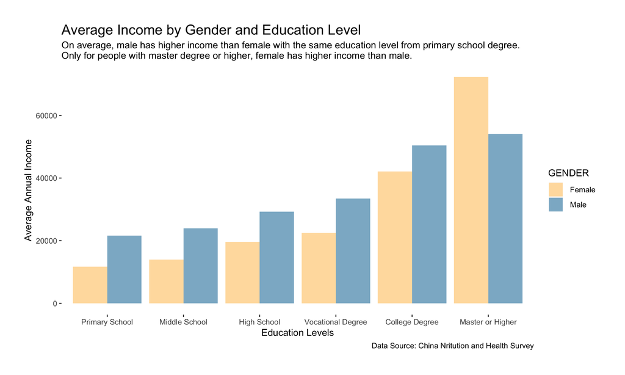

## Visualization 2

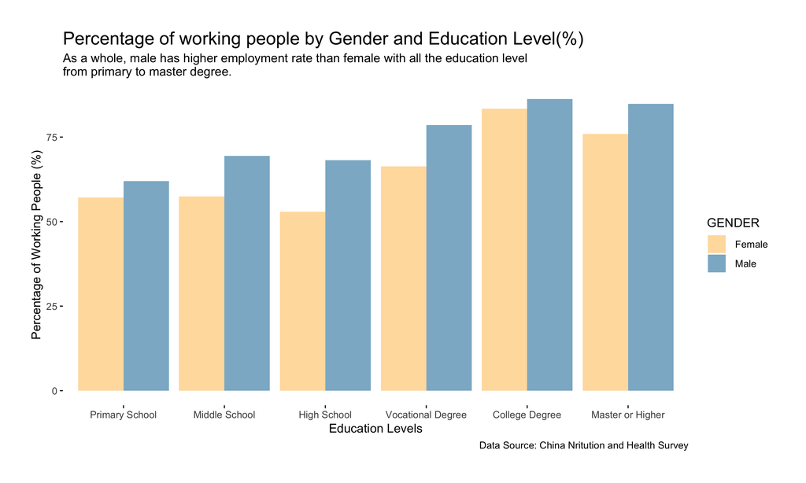

## Visualization 3

[figure not shown]

## Visualization 4

[figure not shown]

## Results 1: Logit Table

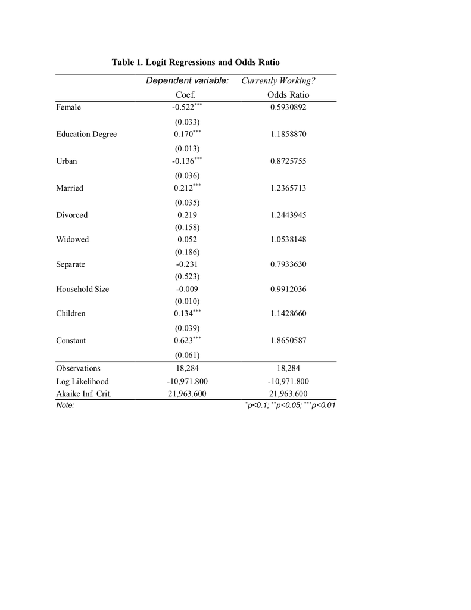

## Results 2: RANDOM ROC Comparison (Logit vs Random Forest)

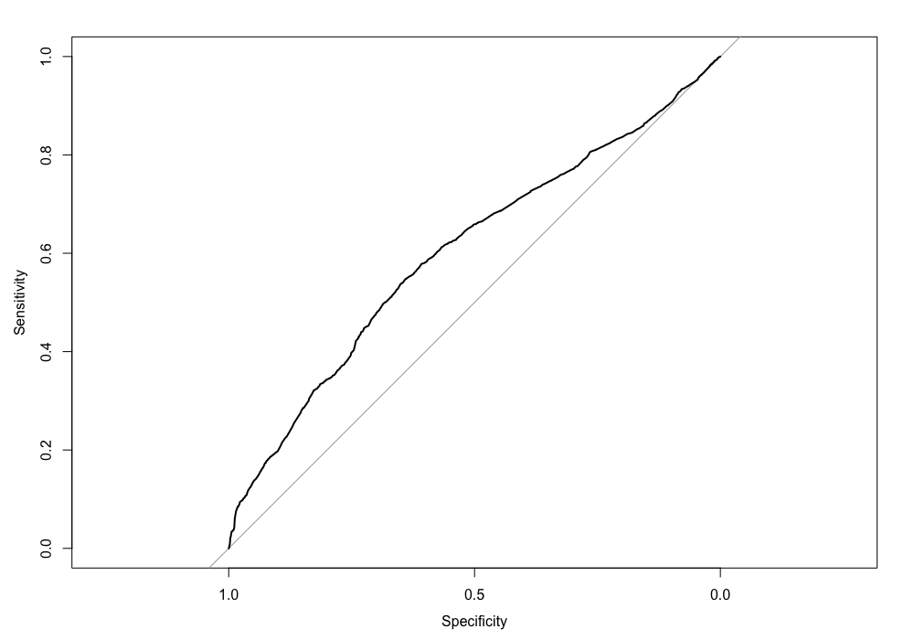

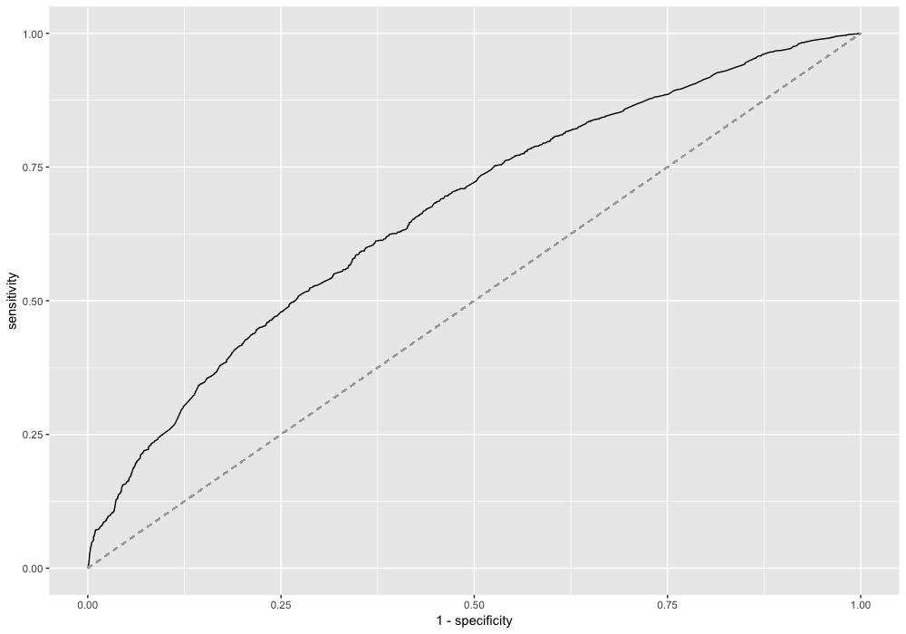

## Results 3: VARIMP

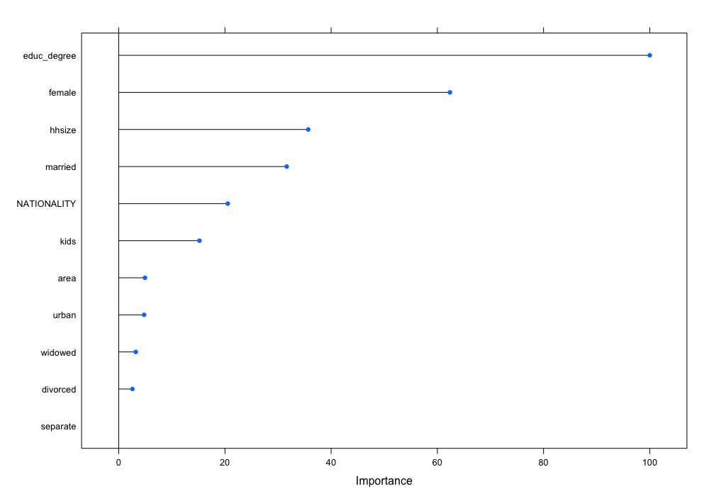

## Lessons Learned

Confirms:

- That disadvantages faced by females in the labor market in China exists

Additionally:

- Education level and gender are two significant indicators of a person’s employment status in China
- As a person’s education level increases, his/her chance of getting education is higher

## Next Steps: Policy Recommendations

In the light of our findings, we recommend:

- Introducing a parental leave policy that equally applies to men
- Introducing an education policy reform that can reduce cost to women of receiving education